# DSR Portfolio Optimizer - Performance Report

Automated Report

February 08, 2026

# Executive Summary

## Key Findings

- **Test Period:** 2023-12-12 to 2024-12-30
- **Rebalance Frequency:** weekly
- **Constraints:** Enabled (30% max weight)
- **Transaction Costs:** 10 bps

### Performance Comparison

Strategy Performance Metrics

| Strategy | Ann. Return | Ann. Vol | Sharpe | Sortino | Calmar | Max DD | VaR@95% | CVaR@95% |
| --- | --- | --- | --- | --- | --- | --- | --- | --- |
| DSR_Constrained | 52.60% | 20.98% | 2.506 | 0.202 | 3.676 | 14.31% | 2.17% | 2.99% |
| DSR_Unconstrained | 69.12% | 22.92% | 3.016 | 0.245 | 5.369 | 12.87% | 2.11% | 3.01% |
| EqualWeight | 43.19% | 20.25% | 2.133 | 0.173 | 2.992 | 14.43% | 2.17% | 3.01% |

### Final Portfolio Values

Starting with $1.00:

| Strategy | Final Value | Total Return |
| --- | --- | --- |
| DSR_Constrained | $1.56 | 55.7% |
| DSR_Unconstrained | $1.73 | 73.4% |
| EqualWeight | $1.46 | 45.7% |

## Equity Curves

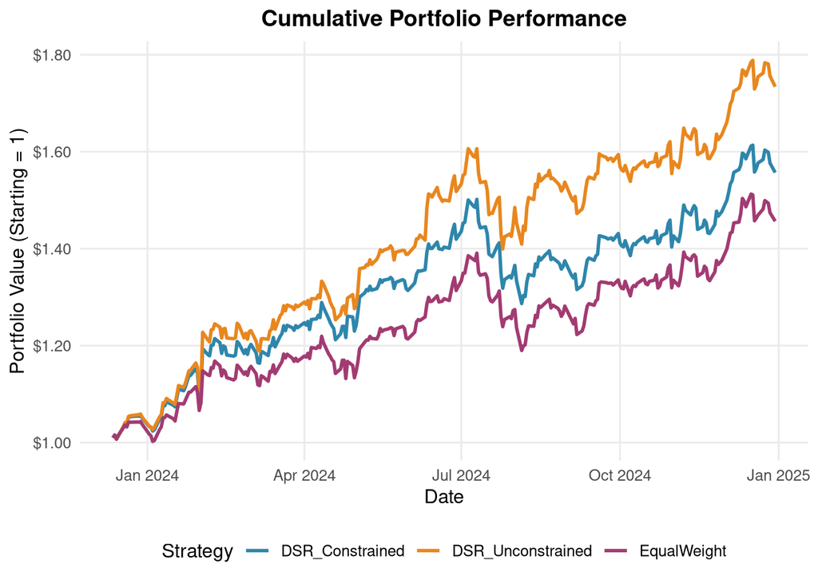

# Monthly Returns Analysis

## Heatmap

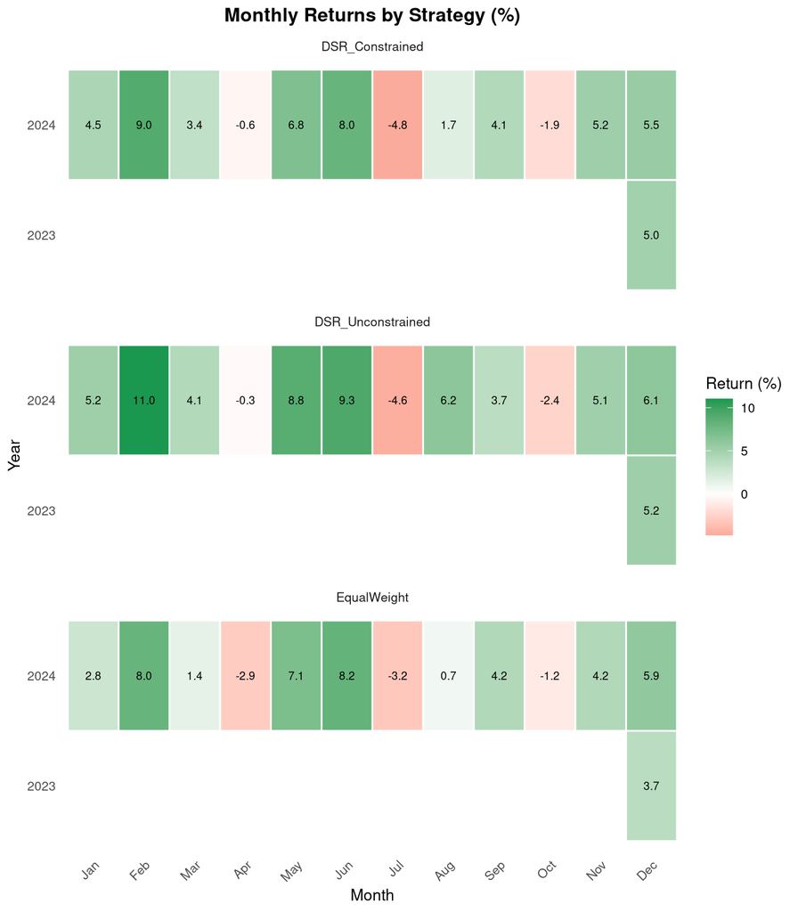

## Monthly Statistics

Monthly Return Statistics

| Strategy | Best Month | Worst Month | Avg Month | Positive Months |
| --- | --- | --- | --- | --- |
| DSR_Constrained | 9.0% | -4.8% | 3.5% | 77% |
| DSR_Unconstrained | 11.0% | -4.6% | 4.4% | 77% |
| EqualWeight | 8.2% | -3.2% | 3.0% | 77% |

# Rolling Performance

## Rolling Sharpe Ratio

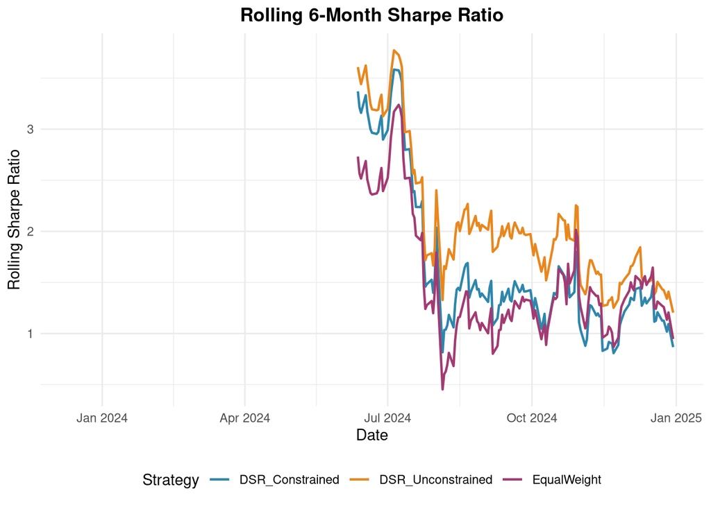

## Rolling Volatility

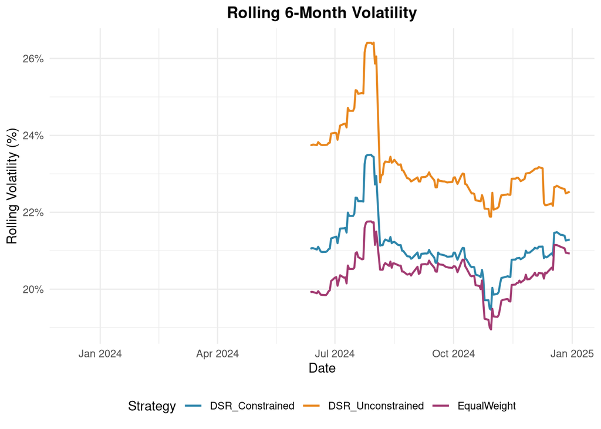

# Drawdown Analysis

## Underwater Chart

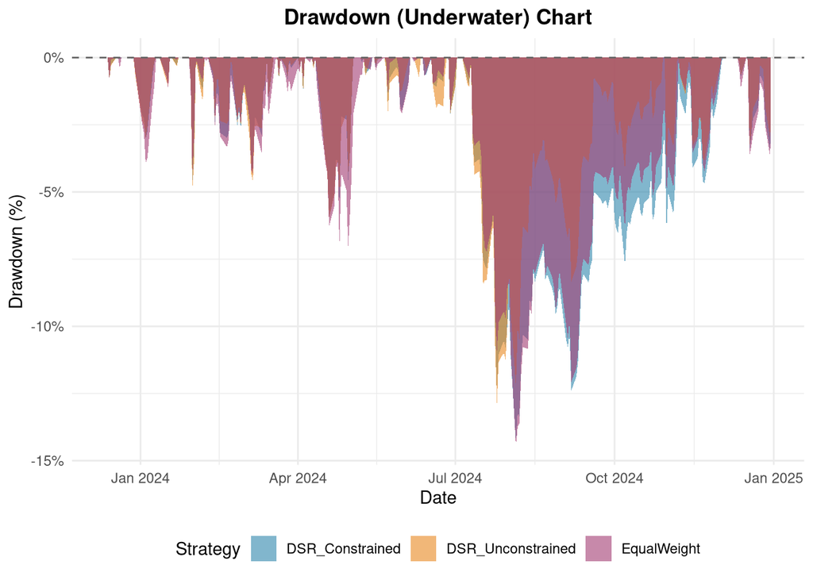

## Drawdown Statistics

Drawdown Statistics

| Strategy | Max Drawdown | Avg Drawdown | Time Underwater |
| --- | --- | --- | --- |
| DSR_Constrained | 14.31% | 4.19% | 76.1% |
| DSR_Unconstrained | 12.87% | 2.93% | 74.2% |
| EqualWeight | 14.43% | 3.83% | 79.9% |

# Risk Metrics

## VaR and CVaR

Risk Metrics (Daily)

| Strategy | VaR (95%) | CVaR (95%) | Max Drawdown | Calmar Ratio |
| --- | --- | --- | --- | --- |
| DSR_Constrained | 2.17% | 2.99% | 14.31% | 3.676 |
| DSR_Unconstrained | 2.11% | 3.01% | 12.87% | 5.369 |
| EqualWeight | 2.17% | 3.01% | 14.43% | 2.992 |

## Risk-Return Scatter

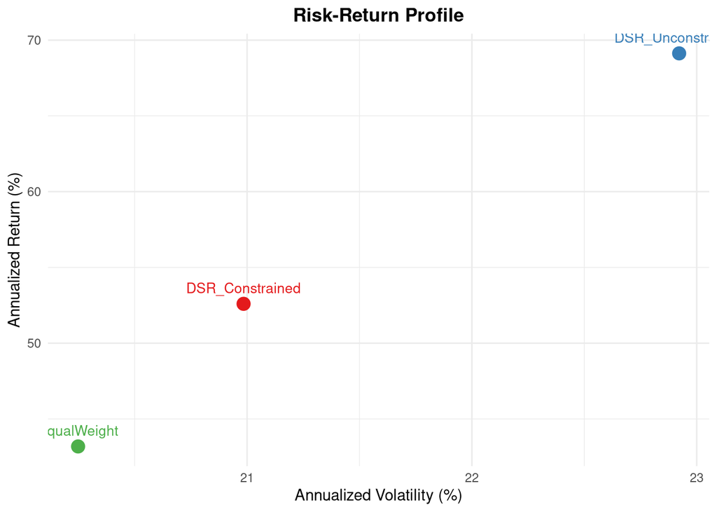

# Regime Analysis

## High Volatility Periods

High-volatility periods identified (annualized vol > 25%):

| Period | Start | End | Duration |
| --- | --- | --- | --- |
| 1 | 2024-02-02 | 2024-03-01 | 29 |
| 2 | 2024-05-01 | 2024-05-10 | 10 |
| 3 | 2024-07-24 | 2024-08-01 | 9 |
| 4 | 2024-08-05 | 2024-08-20 | 16 |

## Performance During Stress

Performance During High-Vol Regimes

| Regime | Strategy | Total Return | Volatility | Max DD |
| --- | --- | --- | --- | --- |
| 1 | DSR_Constrained | 8.2% | 31.7% | 3.0% |
| 1 | DSR_Unconstrained | 9.9% | 39.4% | 2.6% |
| 1 | EqualWeight | 6.9% | 27.0% | 3.3% |
| 2 | DSR_Constrained | 6.9% | 16.8% | 0.6% |
| 2 | DSR_Unconstrained | 7.2% | 21.7% | 0.7% |
| 2 | EqualWeight | 7.1% | 14.2% | 0.4% |
| 3 | DSR_Constrained | -3.3% | 34.3% | 6.6% |
| 3 | DSR_Unconstrained | -1.4% | 42.1% | 7.1% |
| 3 | EqualWeight | -2.9% | 29.8% | 5.6% |
| 4 | DSR_Constrained | 4.3% | 24.5% | 3.5% |
| 4 | DSR_Unconstrained | 6.7% | 28.2% | 3.0% |
| 4 | EqualWeight | 4.4% | 25.0% | 3.8% |

# Weight Analysis

## Average Weights

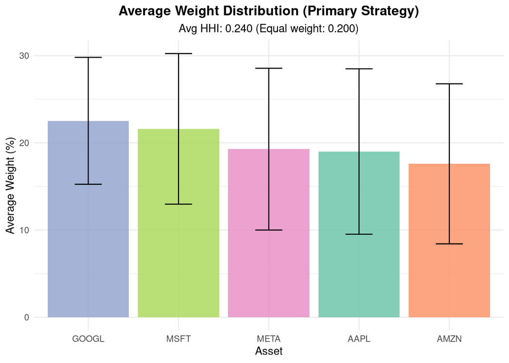

## Weight Statistics

Weight Statistics by Asset

| Asset | Mean (%) | Std (%) | Min (%) | Max (%) |
| --- | --- | --- | --- | --- |
| AAPL | 19.0 | 9.5 | 4.5 | 30.0 |
| MSFT | 21.6 | 8.6 | 5.1 | 30.0 |
| GOOGL | 22.5 | 7.3 | 10.2 | 30.0 |
| AMZN | 17.6 | 9.2 | 4.9 | 30.0 |
| META | 19.3 | 9.3 | 6.3 | 30.0 |

Portfolio Concentration (HHI) = 0.2397 (Equal weight HHI = 0.2000)

## Weight Over Time

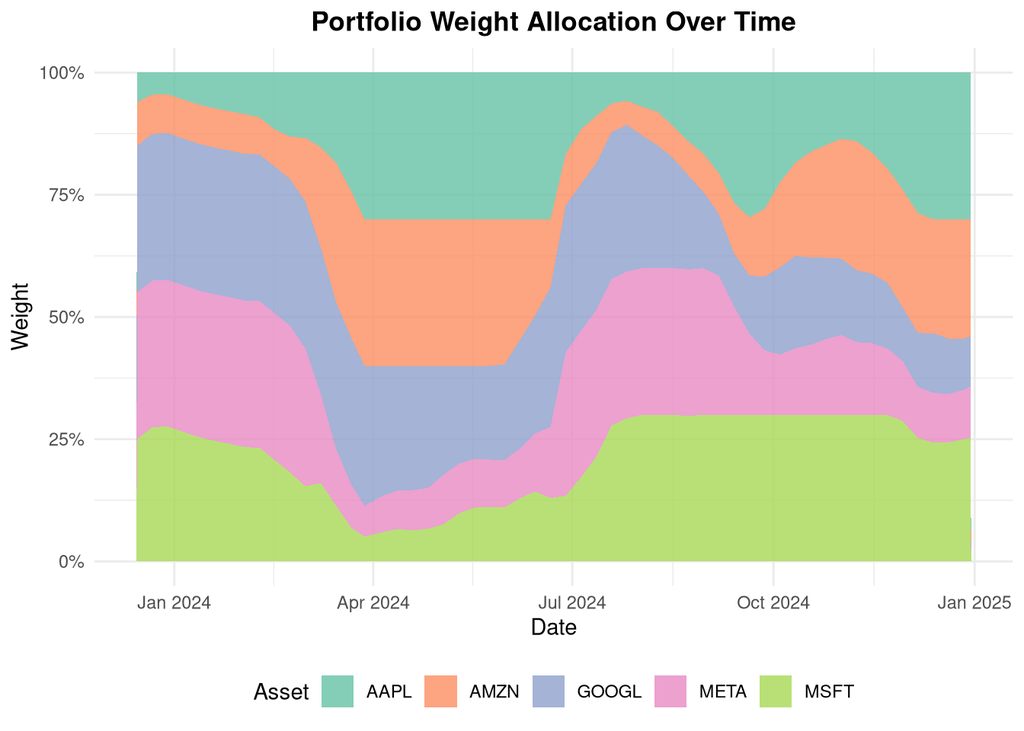

# Turnover Analysis

## Turnover Metrics

Turnover Comparison

| Portfolio | Total Turnover | Avg per Rebalance | Max Turnover | Transaction Costs |
| --- | --- | --- | --- | --- |
| Constrained | 2.93 | 3.51% | 16.72% | 0.59% |
| Unconstrained | 4.61 | 6.56% | 28.96% | 0.92% |

# Appendix

## Configuration

**Assets:** AAPL, MSFT, GOOGL, AMZN, META

**Data Period:** 2018-01-01 to 2024-12-31

**Model Parameters:**

- Lookback Window: 60 days
- LSTM Hidden Layers: 128 -> 64
- Dropout: 0.30
- DSR Eta: 0.0100

**Training Parameters:**

- Train/Val/Test Split: 0.70 / 0.15 / 0.15
- Batch Size: 32
- Learning Rate: 0.0010

**Constraints:**

- Max Position Weight: 30%
- Min Position Weight: 2%
- CVaR Confidence: 95%

## About This Report

This report was automatically generated by the DSR Portfolio Optimizer.

**Key Components:**

- **DSR Loss**: Differential Sharpe Ratio - enables gradient-based optimization of Sharpe ratio
- **LSTM Model**: 2-layer LSTM network predicts portfolio weights
- **Constraints**: Maximum position weights to limit concentration
- **Transaction Costs**: Applied at each rebalance based on turnover

**Report Generated:** 2026-02-08 02:17:55.819349

*Report generated with R Markdown*